# Modello Statistico per Prevedere il Peso dei Neonati

Francesco Gardini

2024-01-12

# Descrizione del Dataset e obiettivo dello studio

Questo progetto mira ad indagare le relazioni tra le variabili, sia quelle riferite alla madre sia quelle riferite al neonato, e il peso del nascituro. .

```r
dati = read.csv('neonati.csv')
attach(dati)
n=nrow(dati)
dati$Tipo.parto = factor(dati$Tipo.parto)
dati$Fumatrici = factor(dati$Fumatrici)
dati$Ospedale = factor(dati$Ospedale)
dati$Sesso = factor(dati$Sesso)
```

### Variabili quantitative

Di seguito sono riportati massimo e minimo, media, mediana, 25° e 75° percentile per le variabiali quantititative del dataset.

```r
var_quant = c('Anni.madre',
              'N.gravidanze',
              'Gestazione',
              'Peso',
              'Lunghezza',
              'Cranio')

summary(dati[,var_quant])
```

```
##    Anni.madre     N.gravidanze       Gestazione         Peso
##  Min.   : 0.00   Min.   : 0.0000   Min.   :25.00   Min.   : 830
##  1st Qu.:25.00   1st Qu.: 0.0000   1st Qu.:38.00   1st Qu.:2990
##  Median :28.00   Median : 1.0000   Median :39.00   Median :3300
##  Mean   :28.16   Mean   : 0.9812   Mean   :38.98   Mean   :3284
##  3rd Qu.:32.00   3rd Qu.: 1.0000   3rd Qu.:40.00   3rd Qu.:3620
##  Max.   :46.00   Max.   :12.0000   Max.   :43.00   Max.   :4930
##    Lunghezza         Cranio
##  Min.   :310.0   Min.   :235
##  1st Qu.:480.0   1st Qu.:330
##  Median :500.0   Median :340
##  Mean   :494.7   Mean   :340
##  3rd Qu.:510.0   3rd Qu.:350
##  Max.   :565.0   Max.   :390
```

```r
which(Anni.madre < 10)
```

```
## [1] 1152 1380
```

```r
dati[which(Anni.madre < 10),]
```

```
##      Anni.madre N.gravidanze Fumatrici Gestazione Peso Lunghezza Cranio
## 1152          1            1         0         41 3250       490    350
## 1380          0            0         0         39 3060       490    330
##      Tipo.parto Ospedale Sesso
## 1152        Nat     osp2     F
## 1380        Nat     osp3     M
```

```r
dati = dati[-c(1380,1152),]
row.names(dati)=NULL
```

### Variabili qualitative

Per le variabili qualitative sono state riportate le frequenze assolute e relative delle rispettive modalità.

```r
ni=table(Fumatrici)
fi=round(ni/n,2)
distr_freq_fum = as.data.frame(cbind(ni,fi))

ni=table(Tipo.parto)
fi=round(ni/n,2)
distr_freq_parto = as.data.frame(cbind(ni,fi))


ni=table(Ospedale)
fi=round(ni/n,2)
distr_freq_osp = as.data.frame(cbind(ni,fi))


ni=table(Sesso)
fi=round(ni/n,2)
distr_freq_sesso = as.data.frame(cbind(ni,fi))

distr_freq_fum
```

```
##     ni   fi
## 0 2396 0.96
## 1  104 0.04
```

```r
distr_freq_parto
```

```
##       ni   fi
## Ces  728 0.29
## Nat 1772 0.71
```

```r
distr_freq_osp
```

```
##       ni   fi
## osp1 816 0.33
## osp2 849 0.34
## osp3 835 0.33
```

```r
distr_freq_sesso
```

```
##     ni  fi
## F 1256 0.5
## M 1244 0.5
```

```r
#library(kableExtra)

#kable(distr_freq_fum, caption = "Fumatrici") %>%
#kable_styling(full_width = FALSE)

#kable(distr_freq_parto, caption = "Tipo di Parto") %>%
#kable_styling(full_width = FALSE)

#kable(distr_freq_osp, caption = "Ospedale") %>%
#kable_styling(full_width = FALSE)

#kable(distr_freq_sesso, caption = "Sesso") %>%
#kable_styling(full_width = FALSE)
```

Si nota come la stragrande maggioranza delle madri (96%) non fumi e che il tipo di parto prevalente è quello naturale (71%). Le altre due variabili che descrivono rispettivemente l’ospedale di provenienza e il sesso si distribuiscono in modo omogeno tra le loro modalità.

### Variabiabile Peso

Di seguito sono riportati il valore degli indici di forma della variabile peso e il risultato del test di Shapiro, utilizzato per determinare se la variabile si distribuisce in modo normale oppure no.

```r
skewness=moments::skewness(dati$Peso)
kurtosi=moments::kurtosis(dati$Peso)-3

skewness
```

```
## [1] -0.6474036
```

```r
kurtosi
```

```
## [1] 2.028753
```

```r
shapiro.test(dati$Peso)
```

```
##
##  Shapiro-Wilk normality test
##
## data:  dati$Peso
## W = 0.97068, p-value < 2.2e-16
```

Il valore negativo di skewnees indica che la distribuzione presenta un’assimetria negativa con una frquenza maggiore per valori maggiori della media, mentre la kurtosi maggiore di zero è indice di una distribi+uzione leptocurtica. Il p-value del test di Shapiro molto minore di 0.05 porta a rifiutare l’ipotesi nulla di normalità. Tutto ciò è ben visibile nel grafico della denistà di probabilià della variabile Peso riportato di seguito.

Tali considerazione dovranno essere tenute presente durante la costruzione e l’analisi del modello statistico.

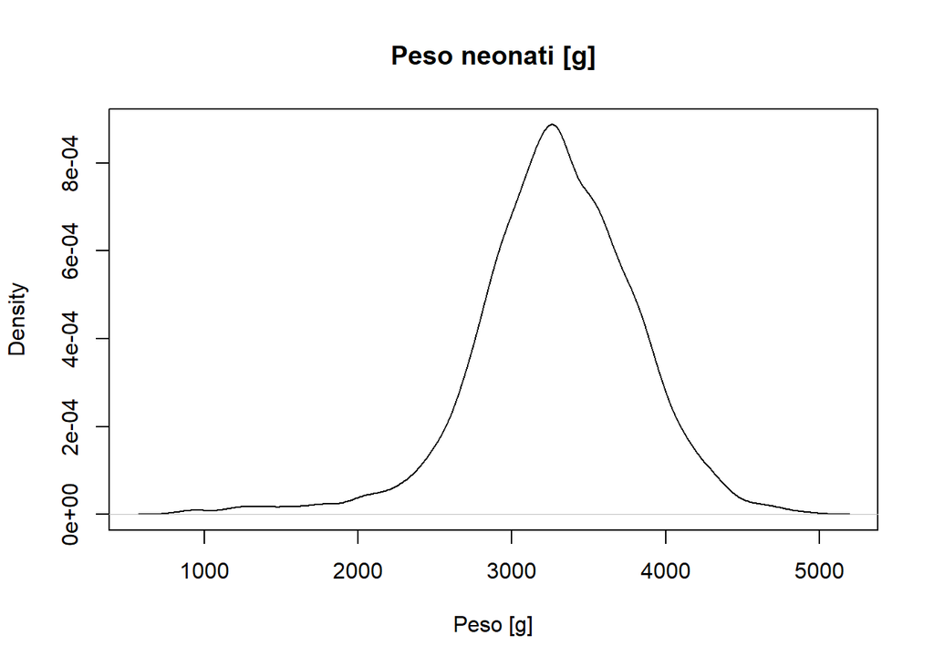

```r
plot(density(dati$Peso),
     main = 'Peso neonati [g]',
     xlab = 'Peso [g]')
```

La densità di probabilità della variabile Peso conferma quanto descritto dagli indici, infatti risulta essere asimmetrica e più “appuntita” rispetto alla distribuzione gaussiana.

### Test di verifica di ipotesi

I seguenti test verificano l’ipotesi di uguaglianza tra la media del campione oggetto di questo studio e quella della popolazione la popalazione per le variabili Peso e lunughezza. Inoltre, si vuole indagare l’ipotesi che tali variabili e quella che descrive la circonferenza del cranio abbiano medie diverse tra maschi e femmine.

I boxplot seguenti mostrano le distribuzioni delle variabili Peso, Lunghezza e Cranio per maschi e femmine.

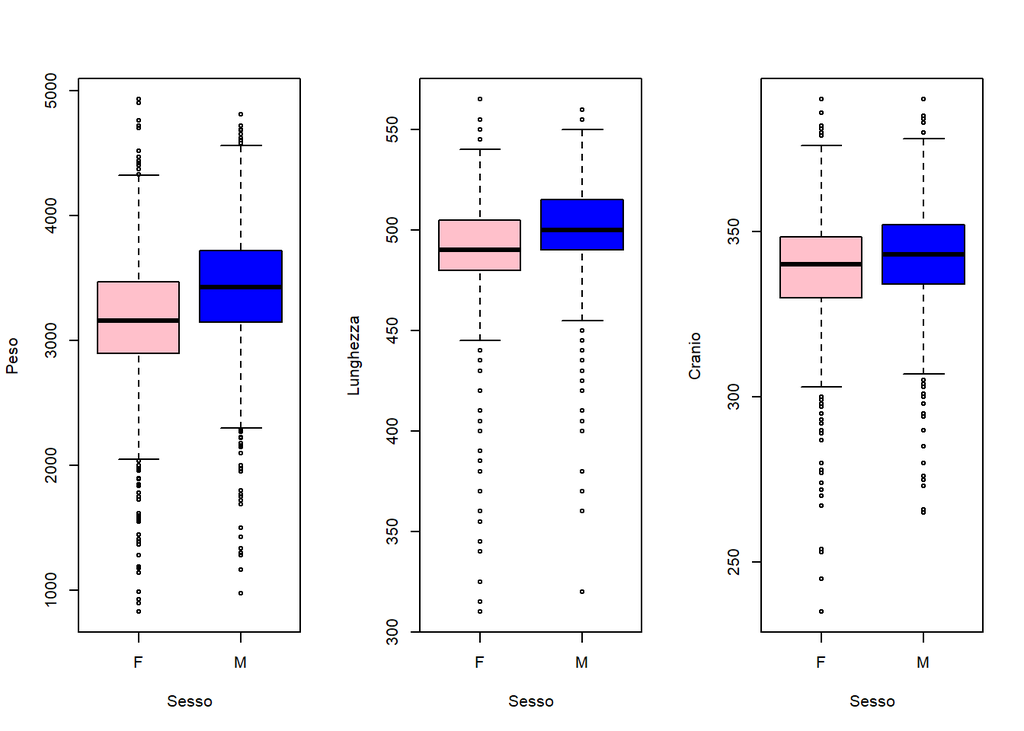

```r
par(mfrow= c(1,3))
boxplot(Peso~Sesso, col=c('pink','blue'))
boxplot(Lunghezza~Sesso, col=c('pink','blue'))
boxplot(Cranio~Sesso, col=c('pink','blue'))
```

Si possono notare differenze tra i due sessi per tutte e tre le variabili, in particolare i maschi mostrano tendenzialmente valori maggiori.

Sono stati svolti dei test di Shapiro per valutare la normalità delle tre variabili così da poter scegliere che tipo di test svolgere.

```r
shapiro.test(dati[dati$Sesso=='M',"Peso"])
```

```
##
##  Shapiro-Wilk normality test
##
## data:  dati[dati$Sesso == "M", "Peso"]
## W = 0.96637, p-value = 2.225e-16
```

```r
shapiro.test(dati[dati$Sesso=='F',"Peso"])
```

```
##
##  Shapiro-Wilk normality test
##
## data:  dati[dati$Sesso == "F", "Peso"]
## W = 0.96293, p-value < 2.2e-16
```

```r
shapiro.test(Peso)
```

```
##
##  Shapiro-Wilk normality test
##
## data:  Peso
## W = 0.97066, p-value < 2.2e-16
```

```r
shapiro.test(dati[dati$Sesso=='M',"Lunghezza"])
```

```
##
##  Shapiro-Wilk normality test
##
## data:  dati[dati$Sesso == "M", "Lunghezza"]
## W = 0.92026, p-value < 2.2e-16
```

```r
shapiro.test(dati[dati$Sesso=='F',"Lunghezza"])
```

```
##
##  Shapiro-Wilk normality test
##
## data:  dati[dati$Sesso == "F", "Lunghezza"]
## W = 0.8996, p-value < 2.2e-16
```

```r
shapiro.test(Lunghezza)
```

```
##
##  Shapiro-Wilk normality test
##
## data:  Lunghezza
## W = 0.90941, p-value < 2.2e-16
```

```r
shapiro.test(dati[dati$Sesso=='M',"Cranio"])
```

```
##
##  Shapiro-Wilk normality test
##
## data:  dati[dati$Sesso == "M", "Cranio"]
## W = 0.97038, p-value = 2.901e-15
```

```r
shapiro.test(dati[dati$Sesso=='F',"Cranio"])
```

```
##
##  Shapiro-Wilk normality test
##
## data:  dati[dati$Sesso == "F", "Cranio"]
## W = 0.95547, p-value < 2.2e-16
```

```r
shapiro.test(Cranio)
```

```
##
##  Shapiro-Wilk normality test
##
## data:  Cranio
## W = 0.96357, p-value < 2.2e-16
```

Dall’esito dei test svolti si può affermare che tutte e tre le variabili non si distribuiscono normalmente sia quando vengono considerate in base al sesso sia quando si considera la distribuzione totale. Quest’osservazione, unita alla presenza di diversi outliers in tutte per tutte e tre le variabili, ha portato alla scelta di un test non parametrico, in particolare quello di Wilcoxon.

Il valore medio del peso del campione è stato confrontato con il valore medio del peso della popolazione. Come valore per la media della popolazione è stato considerato 3,3 Kg, tale valore è in linea con idati relativi alle nascite pubblicati dal MInistero della salute e con quelli consultabili online.

Il valore del p-value maggiore di 0.05 consente di affermare che non c’è una differenza statisticamente significativa tra la media del campione e quella della popolazione.

```r
wilcox.test(x = Peso,
       alternative = 'two.sided',
       mu=3300,
       conf.level=0.95)
```

```
##
##  Wilcoxon signed rank test with continuity correction
##
## data:  Peso
## V = 1495594, p-value = 0.9612
## alternative hypothesis: true location is not equal to 3300
```

Lo stesso tipo di test è stato condotto sulla variabile lunghezza, in questo caso il valore di riferiemtno della popolazione è stato fissato a 50 cm, trovato online. Il p-value snesibilmente minore di 0.05 porta a rifitare l’ipotesi nulla di uguaglianza tra la media del campione in esame e quella della popolazione.

```r
wilcox.test(x=Lunghezza,
       alternative = 'two.sided',
       mu=500,
       conf.level=0.95)
```

```
##
##  Wilcoxon signed rank test with continuity correction
##
## data:  Lunghezza
## V = 877236, p-value < 2.2e-16
## alternative hypothesis: true location is not equal to 500
```

In seguito, si è valutato se ci fossero differenze significative tra i neonati di sesso maschile e quelli di sesso femminile per quanto rigurda peso, lunghezza e circonferenza del cranio.

I valori di p-value molto minori del livello di significatività fissato a 0.05 permettono di affermare che ci sono differenze significative tra maschi e femmine per tutte e tre le variabili

```r
wilcox.test(Peso~Sesso, data = dati)
```

```
##
##  Wilcoxon rank sum test with continuity correction
##
## data:  Peso by Sesso
## W = 537495, p-value < 2.2e-16
## alternative hypothesis: true location shift is not equal to 0
```

```r
wilcox.test(Lunghezza~Sesso, data = dati)
```

```
##
##  Wilcoxon rank sum test with continuity correction
##
## data:  Lunghezza by Sesso
## W = 593412, p-value < 2.2e-16
## alternative hypothesis: true location shift is not equal to 0
```

```r
wilcox.test(Cranio~Sesso, data = dati)
```

```
##
##  Wilcoxon rank sum test with continuity correction
##
## data:  Cranio by Sesso
## W = 639872, p-value = 7.141e-15
## alternative hypothesis: true location shift is not equal to 0
```

Si è indagata la possibile relazione tra il fumo e alcune variabili quali Gestazione, Peso, Lunghezza e Cranio per capire se l’essere fumatrice influisse sulla gravidanza. Per fare ciò sono stati condotti dei Wilcoxon per capire se ci fossero differenze significative tra i due gruppi.

```r
shapiro.test(dati[dati$Fumatrici==1,"Gestazione"])
```

```
##
##  Shapiro-Wilk normality test
##
## data:  dati[dati$Fumatrici == 1, "Gestazione"]
## W = 0.90556, p-value = 1.753e-06
```

```r
shapiro.test(dati[dati$Fumatrici==0,"Gestazione"])
```

```
##
##  Shapiro-Wilk normality test
##
## data:  dati[dati$Fumatrici == 0, "Gestazione"]
## W = 0.83213, p-value < 2.2e-16
```

```r
shapiro.test(dati[dati$Fumatrici==1,"Peso"])
```

```
##
##  Shapiro-Wilk normality test
##
## data:  dati[dati$Fumatrici == 1, "Peso"]
## W = 0.9701, p-value = 0.01867
```

```r
shapiro.test(dati[dati$Fumatrici==0,"Peso"])
```

```
##
##  Shapiro-Wilk normality test
##
## data:  dati[dati$Fumatrici == 0, "Peso"]
## W = 0.96914, p-value < 2.2e-16
```

```r
shapiro.test(dati[dati$Fumatrici==1,"Lunghezza"])
```

```
##
##  Shapiro-Wilk normality test
##
## data:  dati[dati$Fumatrici == 1, "Lunghezza"]
## W = 0.95497, p-value = 0.001384
```

```r
shapiro.test(dati[dati$Fumatrici==0,"Lunghezza"])
```

```
##
##  Shapiro-Wilk normality test
##
## data:  dati[dati$Fumatrici == 0, "Lunghezza"]
## W = 0.90733, p-value < 2.2e-16
```

```r
shapiro.test(dati[dati$Fumatrici==1,"Cranio"])
```

```
##
##  Shapiro-Wilk normality test
##
## data:  dati[dati$Fumatrici == 1, "Cranio"]
## W = 0.99127, p-value = 0.7438
```

```r
shapiro.test(dati[dati$Fumatrici==0,"Cranio"])
```

```
##
##  Shapiro-Wilk normality test
##
## data:  dati[dati$Fumatrici == 0, "Cranio"]
## W = 0.96204, p-value < 2.2e-16
```

Considerato che la maggior parte delle distribuzioni non sono normali, anche in questo caso, è stato scelto il test di Wilcoxon.

```r
wilcox.test(Gestazione~Fumatrici, data = dati)
```

```
##
##  Wilcoxon rank sum test with continuity correction
##
## data:  Gestazione by Fumatrici
## W = 115672, p-value = 0.2099
## alternative hypothesis: true location shift is not equal to 0
```

```r
wilcox.test(Peso~Fumatrici)
```

```
##
##  Wilcoxon rank sum test with continuity correction
##
## data:  Peso by Fumatrici
## W = 138162, p-value = 0.05971
## alternative hypothesis: true location shift is not equal to 0
```

```r
wilcox.test(Lunghezza~Fumatrici)
```

```
##
##  Wilcoxon rank sum test with continuity correction
##
## data:  Lunghezza by Fumatrici
## W = 139508, p-value = 0.0377
## alternative hypothesis: true location shift is not equal to 0
```

```r
wilcox.test(Cranio~Fumatrici)
```

```
##
##  Wilcoxon rank sum test with continuity correction
##
## data:  Cranio by Fumatrici
## W = 131471, p-value = 0.3393
## alternative hypothesis: true location shift is not equal to 0
```

I boxplot di seguito mostrano le distribuzioni delle variabili Gestazione, Peso, Lunghezza e Cranio per fumatrici e non fumatrici.

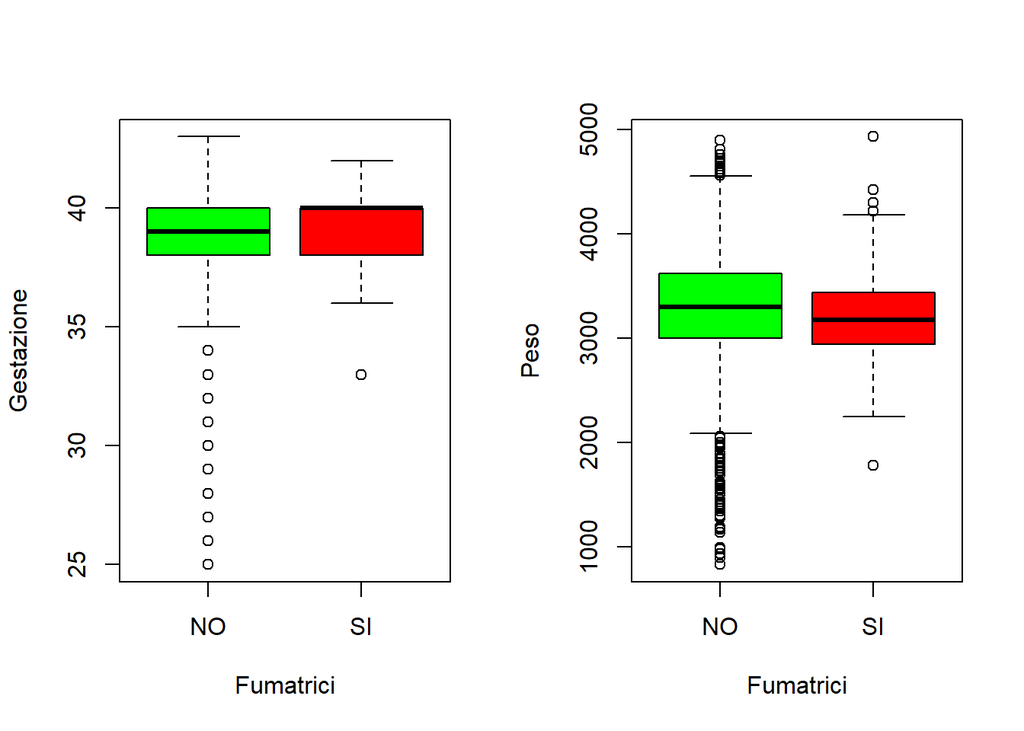

```r
par(mfrow = c(1,2))
boxplot(Gestazione~Fumatrici, col=c('green','red'), names=c('NO','SI'))
boxplot(Peso~Fumatrici,col=c('green','red'), names=c('NO','SI'))
```

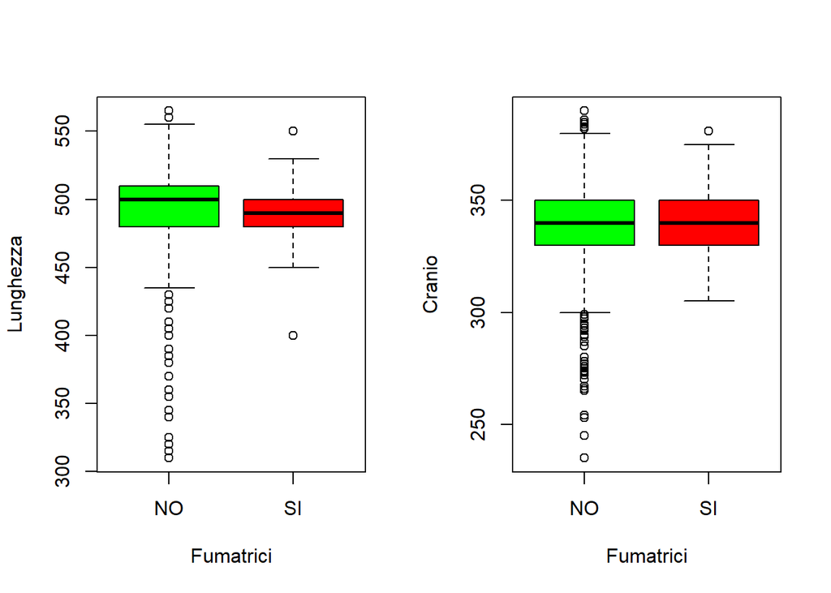

```r
par(mfrow = c(1,2))
boxplot(Lunghezza~Fumatrici, col=c('green','red'), names=c('NO','SI'))
boxplot(Cranio~Fumatrici, col=c('green','red'), names=c('NO','SI'))
```

I risultati dei test mostrano che solo per la variabile lunghezza si evidenziano differenze significative tra i due gruppi.

Infine, si è valutata l’ipotesi che la frequenza dei cesari fosse significativamente diversa tra i diversi ospedali. Per fare ciò è stata costruita la tabella di contingenza delle variabili Tipo.Parto e Ospedale e si è valuatata la loro dipendenza mediante il Test Chi-quadrato di Pearson. Il valore del p-value nettamente maggiore di 0.05 porta a non rifiutare l’ipotesi nulla di indipendenza delle due variabili.

```r
tab_cont_osp_parto = table(Ospedale, Tipo.parto)
chisq.test(tab_cont_osp_parto)
```

```
##
##  Pearson's Chi-squared test
##
## data:  tab_cont_osp_parto
## X-squared = 1.0972, df = 2, p-value = 0.5778
```

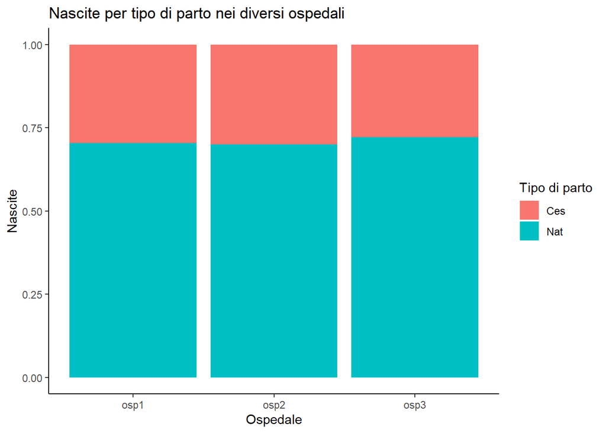

```r
library(ggplot2)
ggplot(data=dati)+
 geom_bar(aes(x=Ospedale, fill=Tipo.parto),
          position = 'fill')+
  theme_classic()+
  labs(fill='Tipo di parto',
       x='Ospedale',
       y='Nascite',
       title = 'Nascite per tipo di parto nei diversi ospedali')
```

# Modello

### Correlazione lineare

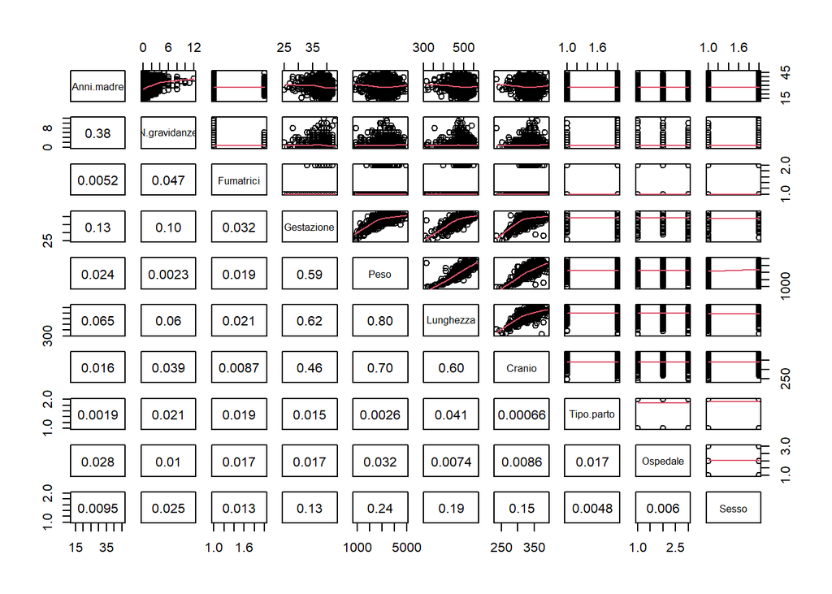

```r
panel.cor <- function(x, y, digits = 2, prefix = "", cex.cor, ...)
{
  par(usr = c(0, 1, 0, 1))
  r <- abs(cor(x, y))
  txt <- format(c(r, 0.123456789), digits = digits)[1]
  txt <- paste0(prefix, txt)
  if(missing(cex.cor)) cex.cor <- 0.8/strwidth(txt)
  text(0.5, 0.5, txt)
}

pairs(dati, upper.panel = panel.smooth, lower.panel = panel.cor)
```

Da una prima analisi della correlazione tra le variabili del dataset e la variabile risposta Peso si può natare che le correlazioni più significative sono con le variabili Lunghezza, Cranio e Gestazione. Con queste variabili, dagli scatter plot, è possibile vedere anche una possibile componente non lineare, soprattutto per la variabile Gestazione.

### Modello di regressione con tutte le variabili

```r
mod1 = lm(Peso ~., data = dati)
summary(mod1)
```

```
##
## Call:
## lm(formula = Peso ~ ., data = dati)
##
## Residuals:
##      Min       1Q   Median       3Q      Max
## -1123.26  -181.53   -14.45   161.05  2611.89
##
## Coefficients:
##                 Estimate Std. Error t value Pr(>|t|)
## (Intercept)   -6735.7960   141.4790 -47.610  < 2e-16 ***
## Anni.madre        0.8018     1.1467   0.699   0.4845
## N.gravidanze     11.3812     4.6686   2.438   0.0148 *
## Fumatrici1      -30.2741    27.5492  -1.099   0.2719
## Gestazione       32.5773     3.8208   8.526  < 2e-16 ***
## Lunghezza        10.2922     0.3009  34.207  < 2e-16 ***
## Cranio           10.4722     0.4263  24.567  < 2e-16 ***
## Tipo.partoNat    29.6335    12.0905   2.451   0.0143 *
## Ospedaleosp2    -11.0912    13.4471  -0.825   0.4096
## Ospedaleosp3     28.2495    13.5054   2.092   0.0366 *
## SessoM           77.5723    11.1865   6.934 5.18e-12 ***
## ---
## Signif. codes:  0 '***' 0.001 '**' 0.01 '*' 0.05 '.' 0.1 ' ' 1
##
## Residual standard error: 274 on 2487 degrees of freedom
## Multiple R-squared:  0.7289, Adjusted R-squared:  0.7278
## F-statistic: 668.7 on 10 and 2487 DF,  p-value: < 2.2e-16
```

Si nota come alcune variabili abbiano un valore di p-value maggiore di 0.05 e quindi non contribuiscano in modo sigificativo a spiegare la varianza della variabile risposta Peso. Nei modelli successivi tali variabili verranno eliminate così da creare un modello più semplice a parità di livello di varianza spiegata.

Dal valore dei coefficienti si evince come quasi tutte le variabili mostrino una correlazione positiva con la variabile esplicativa Peso, ad eccezione della modalità ‘1’ della variabile Fumatrici e della modalità ‘osp2’ della variabile ospedale. In particolare, la variabile Gestazione è quella che provoca l’incremento maggiore della variabile peso in seguito ad un suo aumento. Da notare il significativo aumento del Peso con la modalità ‘M’ della variabile Sesso, in linea con il fatto che siano sate evidenziate differenze significative di peso tra maschi e femmine.

```r
mod2 = update(mod1, ~.-Anni.madre)
summary(mod2)
```

```
##
## Call:
## lm(formula = Peso ~ N.gravidanze + Fumatrici + Gestazione + Lunghezza +
##     Cranio + Tipo.parto + Ospedale + Sesso, data = dati)
##
## Residuals:
##      Min       1Q   Median       3Q      Max
## -1113.82  -180.30   -16.22   160.66  2616.32
##
## Coefficients:
##                 Estimate Std. Error t value Pr(>|t|)
## (Intercept)   -6708.6189   136.0211 -49.320  < 2e-16 ***
## N.gravidanze     12.5833     4.3400   2.899  0.00377 **
## Fumatrici1      -30.4268    27.5455  -1.105  0.26944
## Gestazione       32.2996     3.7997   8.501  < 2e-16 ***
## Lunghezza        10.2916     0.3008  34.209  < 2e-16 ***
## Cranio           10.4874     0.4257  24.638  < 2e-16 ***
## Tipo.partoNat    29.6654    12.0892   2.454  0.01420 *
## Ospedaleosp2    -10.9509    13.4442  -0.815  0.41541
## Ospedaleosp3     28.5171    13.4986   2.113  0.03474 *
## SessoM           77.6452    11.1849   6.942 4.91e-12 ***
## ---
## Signif. codes:  0 '***' 0.001 '**' 0.01 '*' 0.05 '.' 0.1 ' ' 1
##
## Residual standard error: 274 on 2488 degrees of freedom
## Multiple R-squared:  0.7288, Adjusted R-squared:  0.7279
## F-statistic: 743.1 on 9 and 2488 DF,  p-value: < 2.2e-16
```

```r
mod3 = update(mod1, ~.-Fumatrici)
summary(mod3)
```

```
##
## Call:
## lm(formula = Peso ~ Anni.madre + N.gravidanze + Gestazione +
##     Lunghezza + Cranio + Tipo.parto + Ospedale + Sesso, data = dati)
##
## Residuals:
##      Min       1Q   Median       3Q      Max
## -1122.63  -181.96   -14.91   161.39  2615.07
##
## Coefficients:
##                 Estimate Std. Error t value Pr(>|t|)
## (Intercept)   -6735.4444   141.4845 -47.606  < 2e-16 ***
## Anni.madre        0.8118     1.1467   0.708   0.4791
## N.gravidanze     11.1201     4.6627   2.385   0.0172 *
## Gestazione       32.3210     3.8138   8.475  < 2e-16 ***
## Lunghezza        10.3064     0.3006  34.285  < 2e-16 ***
## Cranio           10.4766     0.4263  24.577  < 2e-16 ***
## Tipo.partoNat    29.3770    12.0888   2.430   0.0152 *
## Ospedaleosp2    -11.0363    13.4475  -0.821   0.4119
## Ospedaleosp3     28.5194    13.5038   2.112   0.0348 *
## SessoM           77.3928    11.1858   6.919 5.77e-12 ***
## ---
## Signif. codes:  0 '***' 0.001 '**' 0.01 '*' 0.05 '.' 0.1 ' ' 1
##
## Residual standard error: 274 on 2488 degrees of freedom
## Multiple R-squared:  0.7288, Adjusted R-squared:  0.7278
## F-statistic: 742.8 on 9 and 2488 DF,  p-value: < 2.2e-16
```

Nel modello 2 è stata eleminata la variabile Anni.madre mentre nel modello 3 Fumatrici, nel modello 4 sono state eliminate entrambe. L’indice R-squared Adhiusted, che corrisponde alla percentuale di varianza spiegata dal modello, non varia tra i 4 modelli.

```r
mod4 = update(mod1, ~.-Fumatrici-Anni.madre)
summary(mod4)
```

```
##
## Call:
## lm(formula = Peso ~ N.gravidanze + Gestazione + Lunghezza + Cranio +
##     Tipo.parto + Ospedale + Sesso, data = dati)
##
## Residuals:
##      Min       1Q   Median       3Q      Max
## -1113.07  -181.71   -16.66   161.08  2619.57
##
## Coefficients:
##                 Estimate Std. Error t value Pr(>|t|)
## (Intercept)   -6707.9252   136.0257 -49.314  < 2e-16 ***
## N.gravidanze     12.3360     4.3344   2.846  0.00446 **
## Gestazione       32.0386     3.7925   8.448  < 2e-16 ***
## Lunghezza        10.3059     0.3006  34.286  < 2e-16 ***
## Cranio           10.4920     0.4257  24.648  < 2e-16 ***
## Tipo.partoNat    29.4080    12.0875   2.433  0.01505 *
## Ospedaleosp2    -10.8939    13.4447  -0.810  0.41786
## Ospedaleosp3     28.7917    13.4969   2.133  0.03301 *
## SessoM           77.4657    11.1842   6.926 5.48e-12 ***
## ---
## Signif. codes:  0 '***' 0.001 '**' 0.01 '*' 0.05 '.' 0.1 ' ' 1
##
## Residual standard error: 274 on 2489 degrees of freedom
## Multiple R-squared:  0.7287, Adjusted R-squared:  0.7278
## F-statistic: 835.7 on 8 and 2489 DF,  p-value: < 2.2e-16
```

Il test ANOVA può esssere utilizzato per confrontare due modelli e valutare se ci sono differenze significative in termini di varianza spiegata tra i due. Il p-value nettamente maggiore di 0.05 consente di affermare non ci sono differenze significative tra il modello iniziale (mod1) e il modello in cui non sono state considarate le variabili Anni.madre e Fumatrici (mod4)

```r
anova(mod1,mod4)
```

```
## Analysis of Variance Table
##
## Model 1: Peso ~ Anni.madre + N.gravidanze + Fumatrici + Gestazione + Lunghezza +
##     Cranio + Tipo.parto + Ospedale + Sesso
## Model 2: Peso ~ N.gravidanze + Gestazione + Lunghezza + Cranio + Tipo.parto +
##     Ospedale + Sesso
##   Res.Df       RSS Df Sum of Sq      F Pr(>F)
## 1   2487 186743194
## 2   2489 186871503 -2   -128309 0.8544 0.4257
```

La funzione stepAIC è stata usata per creare un modello utilizzando il metodo di ottimizzazione stepwise in modo automatico.

```r
library(MASS)

mod_stepwise = stepAIC(mod1,
                       direction = 'both',
                       k = log(n))
```

```
## Start:  AIC=28118.62
## Peso ~ Anni.madre + N.gravidanze + Fumatrici + Gestazione + Lunghezza +
##     Cranio + Tipo.parto + Ospedale + Sesso
##
##                Df Sum of Sq       RSS   AIC
## - Anni.madre    1     36710 186779904 28111
## - Fumatrici     1     90677 186833870 28112
## - Ospedale      2    687555 187430749 28112
## - N.gravidanze  1    446244 187189438 28117
## - Tipo.parto    1    451073 187194266 28117
## <none>                      186743194 28119
## - Sesso         1   3610705 190353899 28159
## - Gestazione    1   5458852 192202046 28183
## - Cranio        1  45318506 232061700 28654
## - Lunghezza     1  87861708 274604902 29074
##
## Step:  AIC=28111.29
## Peso ~ N.gravidanze + Fumatrici + Gestazione + Lunghezza + Cranio +
##     Tipo.parto + Ospedale + Sesso
##
##                Df Sum of Sq       RSS   AIC
## - Fumatrici     1     91599 186871503 28105
## - Ospedale      2    693914 187473818 28105
## - Tipo.parto    1    452049 187231953 28110
## <none>                      186779904 28111
## - N.gravidanze  1    631082 187410986 28112
## + Anni.madre    1     36710 186743194 28119
## - Sesso         1   3617809 190397713 28151
## - Gestazione    1   5424800 192204704 28175
## - Cranio        1  45569477 232349381 28649
## - Lunghezza     1  87852027 274631931 29066
##
## Step:  AIC=28104.69
## Peso ~ N.gravidanze + Gestazione + Lunghezza + Cranio + Tipo.parto +
##     Ospedale + Sesso
##
##                Df Sum of Sq       RSS   AIC
## - Ospedale      2    702925 187574428 28098
## - Tipo.parto    1    444404 187315907 28103
## <none>                      186871503 28105
```

[output cut: 23 more lines]

```
##
## Step:  AIC=28096.81
## Peso ~ N.gravidanze + Gestazione + Lunghezza + Cranio + Sesso
##
##                Df Sum of Sq       RSS   AIC
## <none>                      188042054 28097
## - N.gravidanze  1    621053 188663107 28097
## + Tipo.parto    1    467626 187574428 28098
## + Ospedale      2    726146 187315907 28103
## + Fumatrici     1     92548 187949505 28103
## + Anni.madre    1     45366 187996688 28104
## - Sesso         1   3650790 191692844 28137
## - Gestazione    1   5477493 193519547 28161
## - Cranio        1  46098547 234140601 28637
## - Lunghezza     1  87532691 275574744 29044
```

```r
summary(mod_stepwise)
```

```
##
## Call:
## lm(formula = Peso ~ N.gravidanze + Gestazione + Lunghezza + Cranio +
##     Sesso, data = dati)
##
## Residuals:
##      Min       1Q   Median       3Q      Max
## -1149.37  -180.98   -15.57   163.69  2639.09
##
## Coefficients:
##                Estimate Std. Error t value Pr(>|t|)
## (Intercept)  -6681.7251   135.8036 -49.201  < 2e-16 ***
## N.gravidanze    12.4554     4.3416   2.869  0.00415 **
## Gestazione      32.3827     3.8008   8.520  < 2e-16 ***
## Lunghezza       10.2455     0.3008  34.059  < 2e-16 ***
## Cranio          10.5410     0.4265  24.717  < 2e-16 ***
## SessoM          77.9807    11.2111   6.956 4.47e-12 ***
## ---
## Signif. codes:  0 '***' 0.001 '**' 0.01 '*' 0.05 '.' 0.1 ' ' 1
##
## Residual standard error: 274.7 on 2492 degrees of freedom
## Multiple R-squared:  0.727,  Adjusted R-squared:  0.7265
## F-statistic:  1327 on 5 and 2492 DF,  p-value: < 2.2e-16
```

Il modello così creato non utilizza le variabili Tipo.parto e ospedale che invece sono presenti nel modello 4.

Gli indici BIC e AIC possono essere utilizzati per scegliere un modello rispetto ad un altro, si sceglie il modello con l’indice minore

```r
df=BIC(mod4, mod_stepwise)
aic = AIC(mod4, mod_stepwise)
df$AIC = aic$AIC
df
```

```
##              df      BIC      AIC
## mod4         10 35201.52 35143.29
## mod_stepwise  7 35193.65 35152.89
```

```r
anova(mod4, mod_stepwise)
```

```
## Analysis of Variance Table
##
## Model 1: Peso ~ N.gravidanze + Gestazione + Lunghezza + Cranio + Tipo.parto +
##     Ospedale + Sesso
## Model 2: Peso ~ N.gravidanze + Gestazione + Lunghezza + Cranio + Sesso
##   Res.Df       RSS Df Sum of Sq     F   Pr(>F)
## 1   2489 186871503
## 2   2492 188042054 -3  -1170550 5.197 0.001405 **
## ---
## Signif. codes:  0 '***' 0.001 '**' 0.01 '*' 0.05 '.' 0.1 ' ' 1
```

L’indice BIC è minore per il modello creato con la funzione automatica mentre il l’AIC è inferiore per il modello selezionato manualmente e contenente più variabili. Considerando che la variabile Tipo.parto risulta significativa così come una delle modalità di quella Ospedale, che il test Anova mostra differenze significative in merito alla varianza spiegata tra i due modelli e che R-squared adjusted è maggiore per il modello scelto manualmente, quest’ultimo è stato preferito.

### Effetti di non linearità

```r
mod5 = update(mod_stepwise, ~.+I(N.gravidanze^2)+I(Gestazione^2)+I(Lunghezza^2)+I(Cranio^2))
summary(mod5)
```

```
##
## Call:
## lm(formula = Peso ~ N.gravidanze + Gestazione + Lunghezza + Cranio +
##     Sesso + I(N.gravidanze^2) + I(Gestazione^2) + I(Lunghezza^2) +
##     I(Cranio^2), data = dati)
##
## Residuals:
##     Min      1Q  Median      3Q     Max
## -1195.5  -182.5   -11.5   162.3  1470.2
##
## Coefficients:
##                     Estimate Std. Error t value Pr(>|t|)
## (Intercept)       -1.075e+03  1.162e+03  -0.925 0.354956
## N.gravidanze       2.821e+01  7.902e+00   3.570 0.000363 ***
## Gestazione         3.688e+02  6.744e+01   5.468 5.00e-08 ***
## Lunghezza         -2.910e+01  4.436e+00  -6.560 6.52e-11 ***
## Cranio            -5.358e+00  9.804e+00  -0.547 0.584743
## SessoM             7.238e+01  1.100e+01   6.581 5.68e-11 ***
## I(N.gravidanze^2) -2.647e+00  1.277e+00  -2.073 0.038246 *
## I(Gestazione^2)   -4.276e+00  8.845e-01  -4.835 1.42e-06 ***
## I(Lunghezza^2)     4.059e-02  4.544e-03   8.933  < 2e-16 ***
## I(Cranio^2)        2.326e-02  1.445e-02   1.610 0.107604
## ---
## Signif. codes:  0 '***' 0.001 '**' 0.01 '*' 0.05 '.' 0.1 ' ' 1
##
## Residual standard error: 268.3 on 2488 degrees of freedom
## Multiple R-squared:  0.7399, Adjusted R-squared:  0.739
## F-statistic: 786.6 on 9 and 2488 DF,  p-value: < 2.2e-16
```

Come si può notare, la componente quadratica della variabile Cranio non è significativa, inoltre, perde di significatività anche la variabile Cranio, che nel modello di partenza, invece, mostrava un p-value molto minore di 0.05.

Nel modello seguente è stata, quindi, eliminata la componente quadratica della variabile cranio.

```r
mod6= update(mod5, ~.-I(Cranio^2))
summary(mod6)
```

```
##
## Call:
## lm(formula = Peso ~ N.gravidanze + Gestazione + Lunghezza + Cranio +
##     Sesso + I(N.gravidanze^2) + I(Gestazione^2) + I(Lunghezza^2),
##     data = dati)
##
## Residuals:
##      Min       1Q   Median       3Q      Max
## -1199.50  -181.63    -9.24   163.15  1402.67
##
## Coefficients:
##                     Estimate Std. Error t value Pr(>|t|)
## (Intercept)       -2.245e+03  9.069e+02  -2.476 0.013363 *
## N.gravidanze       2.810e+01  7.904e+00   3.555 0.000385 ***
## Gestazione         3.291e+02  6.279e+01   5.241 1.73e-07 ***
## Lunghezza         -3.206e+01  4.036e+00  -7.944 2.94e-15 ***
## Cranio             1.041e+01  4.196e-01  24.804  < 2e-16 ***
## SessoM             7.267e+01  1.100e+01   6.607 4.79e-11 ***
## I(N.gravidanze^2) -2.611e+00  1.277e+00  -2.045 0.040986 *
## I(Gestazione^2)   -3.766e+00  8.260e-01  -4.559 5.38e-06 ***
## I(Lunghezza^2)     4.361e-02  4.140e-03  10.535  < 2e-16 ***
## ---
## Signif. codes:  0 '***' 0.001 '**' 0.01 '*' 0.05 '.' 0.1 ' ' 1
##
## Residual standard error: 268.4 on 2489 degrees of freedom
## Multiple R-squared:  0.7397, Adjusted R-squared:  0.7388
## F-statistic:   884 on 8 and 2489 DF,  p-value: < 2.2e-16
```

In seguito all’eliminazione della sua componente non lineare la variabile cranio è nuovamente significativa, come nel modello di partenza.

Questo modello è stato confrontato con il modello di partenza utilizzando gli stessi criteri descritti in precedenza.

```r
df=BIC(mod_stepwise, mod6)
aic = AIC(mod4, mod6)
df$AIC = aic$AIC
df
```

```
##              df      BIC      AIC
## mod_stepwise  7 35193.65 35143.29
## mod6         10 35098.54 35040.31
```

```r
anova(mod_stepwise, mod6)
```

```
## Analysis of Variance Table
##
## Model 1: Peso ~ N.gravidanze + Gestazione + Lunghezza + Cranio + Sesso
## Model 2: Peso ~ N.gravidanze + Gestazione + Lunghezza + Cranio + Sesso +
##     I(N.gravidanze^2) + I(Gestazione^2) + I(Lunghezza^2)
##   Res.Df       RSS Df Sum of Sq      F    Pr(>F)
## 1   2492 188042054
## 2   2489 179324309  3   8717745 40.334 < 2.2e-16 ***
## ---
## Signif. codes:  0 '***' 0.001 '**' 0.01 '*' 0.05 '.' 0.1 ' ' 1
```

### Interazioni tra le variabili

All’ultimo modello contente anche gli effetti non lineari di alcune variabili sono stati aggiunti dei termini per tenere conto dei possibili effetti di interazione tra le variabili. In particolare si è valutata l’interazione tra le variabili Gestazione, Lunghezza e Cranio.

```r
mod7 = update(mod6, ~.+Gestazione*Lunghezza)
summary(mod7)
```

```
##
## Call:
## lm(formula = Peso ~ N.gravidanze + Gestazione + Lunghezza + Cranio +
##     Sesso + I(N.gravidanze^2) + I(Gestazione^2) + I(Lunghezza^2) +
##     Gestazione:Lunghezza, data = dati)
##
## Residuals:
##      Min       1Q   Median       3Q      Max
## -1216.88  -181.98   -10.95   163.30  1332.89
##
## Coefficients:
##                        Estimate Std. Error t value Pr(>|t|)
## (Intercept)          -2.571e+03  9.208e+02  -2.792 0.005281 **
## N.gravidanze          2.823e+01  7.899e+00   3.574 0.000358 ***
## Gestazione            2.986e+02  6.457e+01   4.625 3.93e-06 ***
## Lunghezza            -2.831e+01  4.448e+00  -6.364 2.33e-10 ***
## Cranio                1.033e+01  4.212e-01  24.520  < 2e-16 ***
## SessoM                7.365e+01  1.100e+01   6.693 2.69e-11 ***
## I(N.gravidanze^2)    -2.648e+00  1.276e+00  -2.075 0.038104 *
## I(Gestazione^2)      -1.196e+00  1.525e+00  -0.784 0.433084
## I(Lunghezza^2)        5.338e-02  6.395e-03   8.348  < 2e-16 ***
## Gestazione:Lunghezza -3.434e-01  1.713e-01  -2.004 0.045179 *
## ---
## Signif. codes:  0 '***' 0.001 '**' 0.01 '*' 0.05 '.' 0.1 ' ' 1
##
## Residual standard error: 268.3 on 2488 degrees of freedom
## Multiple R-squared:  0.7401, Adjusted R-squared:  0.7392
## F-statistic: 787.2 on 9 and 2488 DF,  p-value: < 2.2e-16
```

```r
mod8 = update(mod6, ~.+Gestazione*Cranio)
summary(mod8)
```

```
##
## Call:
## lm(formula = Peso ~ N.gravidanze + Gestazione + Lunghezza + Cranio +
##     Sesso + I(N.gravidanze^2) + I(Gestazione^2) + I(Lunghezza^2) +
##     Gestazione:Cranio, data = dati)
##
## Residuals:
##      Min       1Q   Median       3Q      Max
## -1193.62  -181.42   -10.31   164.72  1549.69
##
## Coefficients:
##                     Estimate Std. Error t value Pr(>|t|)
## (Intercept)       -6.152e+02  1.094e+03  -0.562 0.574057
## N.gravidanze       2.929e+01  7.907e+00   3.704 0.000217 ***
## Gestazione         3.198e+02  6.282e+01   5.091 3.83e-07 ***
## Lunghezza         -2.737e+01  4.402e+00  -6.217 5.91e-10 ***
## Cranio            -4.985e+00  5.816e+00  -0.857 0.391486
## SessoM             7.182e+01  1.099e+01   6.534 7.74e-11 ***
## I(N.gravidanze^2) -2.810e+00  1.278e+00  -2.199 0.027952 *
## I(Gestazione^2)   -5.392e+00  1.028e+00  -5.247 1.68e-07 ***
## I(Lunghezza^2)     3.880e-02  4.515e-03   8.592  < 2e-16 ***
## Gestazione:Cranio  3.997e-01  1.506e-01   2.654 0.008016 **
## ---
## Signif. codes:  0 '***' 0.001 '**' 0.01 '*' 0.05 '.' 0.1 ' ' 1
##
## Residual standard error: 268.1 on 2488 degrees of freedom
## Multiple R-squared:  0.7404, Adjusted R-squared:  0.7395
## F-statistic: 788.5 on 9 and 2488 DF,  p-value: < 2.2e-16
```

```r
mod9 = update(mod6, ~.+Lunghezza*Cranio)
summary(mod9)
```

```
##
## Call:
## lm(formula = Peso ~ N.gravidanze + Gestazione + Lunghezza + Cranio +
##     Sesso + I(N.gravidanze^2) + I(Gestazione^2) + I(Lunghezza^2) +
##     Lunghezza:Cranio, data = dati)
##
## Residuals:
##      Min       1Q   Median       3Q      Max
## -1200.01  -181.34    -9.41   164.09  1330.50
##
## Coefficients:
##                     Estimate Std. Error t value Pr(>|t|)
## (Intercept)       -3.278e+03  1.050e+03  -3.124 0.001806 **
## N.gravidanze       2.803e+01  7.899e+00   3.548 0.000395 ***
## Gestazione         2.792e+02  6.777e+01   4.120 3.92e-05 ***
## Lunghezza         -3.074e+01  4.091e+00  -7.516 7.84e-14 ***
## Cranio             2.031e+01  5.089e+00   3.991 6.76e-05 ***
## SessoM             7.333e+01  1.100e+01   6.667 3.20e-11 ***
## I(N.gravidanze^2) -2.593e+00  1.276e+00  -2.032 0.042275 *
## I(Gestazione^2)   -3.125e+00  8.885e-01  -3.517 0.000445 ***
## I(Lunghezza^2)     4.933e-02  5.069e-03   9.732  < 2e-16 ***
## Lunghezza:Cranio  -2.032e-02  1.040e-02  -1.953 0.050962 .
## ---
## Signif. codes:  0 '***' 0.001 '**' 0.01 '*' 0.05 '.' 0.1 ' ' 1
##
## Residual standard error: 268.3 on 2488 degrees of freedom
## Multiple R-squared:  0.7401, Adjusted R-squared:  0.7391
## F-statistic: 787.1 on 9 and 2488 DF,  p-value: < 2.2e-16
```

```r
mod10 = update(mod6, ~.+Gestazione*Cranio+Gestazione*Lunghezza+Lunghezza*Cranio)
summary(mod10)
```

```
##
## Call:
## lm(formula = Peso ~ N.gravidanze + Gestazione + Lunghezza + Cranio +
##     Sesso + I(N.gravidanze^2) + I(Gestazione^2) + I(Lunghezza^2) +
##     Gestazione:Cranio + Gestazione:Lunghezza + Lunghezza:Cranio,
##     data = dati)
##
## Residuals:
##      Min       1Q   Median       3Q      Max
## -1203.68  -182.02    -8.93   164.76  1321.03
##
## Coefficients:
##                        Estimate Std. Error t value Pr(>|t|)
## (Intercept)          -1.103e+03  1.107e+03  -0.996   0.3192
## N.gravidanze          3.157e+01  7.872e+00   4.010 6.25e-05 ***
## Gestazione            1.069e+02  7.353e+01   1.454   0.1461
## Lunghezza            -9.641e+00  5.525e+00  -1.745   0.0811 .
## Cranio               -3.530e+00  6.744e+00  -0.524   0.6007
## SessoM                7.338e+01  1.093e+01   6.710 2.40e-11 ***
## I(N.gravidanze^2)    -3.185e+00  1.272e+00  -2.503   0.0124 *
## I(Gestazione^2)      -3.573e+00  1.584e+00  -2.256   0.0242 *
## I(Lunghezza^2)        5.889e-02  6.451e-03   9.129  < 2e-16 ***
## Gestazione:Cranio     1.182e+00  2.069e-01   5.715 1.23e-08 ***
## Gestazione:Lunghezza -3.944e-01  1.935e-01  -2.038   0.0417 *
## Lunghezza:Cranio     -6.500e-02  1.471e-02  -4.420 1.03e-05 ***
## ---
## Signif. codes:  0 '***' 0.001 '**' 0.01 '*' 0.05 '.' 0.1 ' ' 1
##
## Residual standard error: 266.5 on 2486 degrees of freedom
## Multiple R-squared:  0.7436, Adjusted R-squared:  0.7425
## F-statistic: 655.4 on 11 and 2486 DF,  p-value: < 2.2e-16
```

## Analisi del modello

### Non collinearità dei residui

Affinchè il modello sia affidabile è importante valutare la non correlazione tra i regressori. L’indice VIF è utile per valutare l’eventuale collinearità dei regressori. Essendo presenti nel modello termini non lineari al posto dell’indice VIF è stato calcolato il GVIF, una forma generalizzata del precedente indice. Si nota come per tutti i regressori il GVIF sia minore di 5 il che indica una scarsa collinearità tra i regressori.

```r
library(car)
vif(mod6, type = 'predictor')
```

```
## GVIFs computed for predictors
```

```
##                  GVIF Df GVIF^(1/(2*Df))    Interacts With
## N.gravidanze 1.039495  2        1.009731 I(N.gravidanze^2)
## Gestazione   3.137467  2        1.330898   I(Gestazione^2)
## Lunghezza    3.749170  2        1.391502    I(Lunghezza^2)
## Cranio       1.647067  1        1.283381              --
## Sesso        1.048788  1        1.024104              --
##                                         Other Predictors
## N.gravidanze        Gestazione, Lunghezza, Cranio, Sesso
## Gestazione        N.gravidanze, Lunghezza, Cranio, Sesso
## Lunghezza        N.gravidanze, Gestazione, Cranio, Sesso
## Cranio        N.gravidanze, Gestazione, Lunghezza, Sesso
## Sesso        N.gravidanze, Gestazione, Lunghezza, Cranio
```

### Analisi dei residui

Le ipotesi alla base dei modelli di correlazione che riguardano i residui sono: *Indipendenza: non ci deve essere autocorrelazione tra i residui* Omoschedasticità: la varianza è costante tra i residui *Normalità: i residui si devono distribuire secondo la distribuzione normale

Per valutare tale ipotesi si utilizzano i seguenti grafici e appositi test.

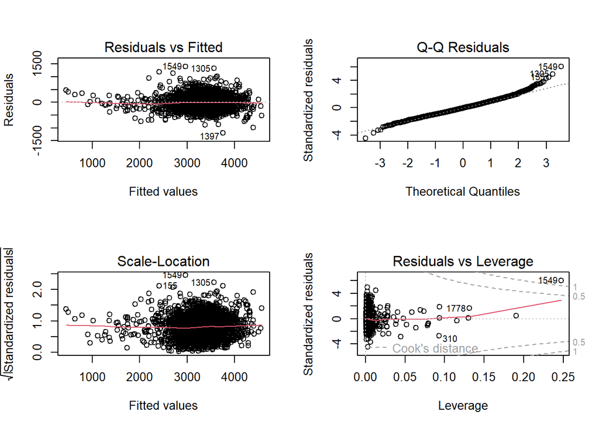

```r
par(mfrow=c(2,2))
plot(mod6)
```

```r
library(lmtest)
bptest(mod6)
```

```
##
##  studentized Breusch-Pagan test
##
## data:  mod6
## BP = 96.029, df = 8, p-value < 2.2e-16
```

```r
dwtest(mod6)
```

```
##
##  Durbin-Watson test
##
## data:  mod6
## DW = 1.9497, p-value = 0.1044
## alternative hypothesis: true autocorrelation is greater than 0
```

```r
shapiro.test(residuals(mod6))
```

```
##
##  Shapiro-Wilk normality test
##
## data:  residuals(mod6)
## W = 0.98905, p-value = 6.586e-13
```

Dal grafico 1 si nota come la maggior parte dei valori previsti sia tra i 2500 e i 4000 grammi, in linea con la distribuzione della variabile peso; sono presenti punti con valori di residuo molto alto e si nota come i valori di residuo maggiore siano per valori alti di peso il che potrebbe essere indice di etoroschedasticità. L’eteorschedasticità è confermata dal Test di Breusch-Pagan il cui valore di p-value molto minore di 0.05 fa rifiutare l’ipotesi nulla di omoschedasticità.

Attraverso il grafico si può vedere come ci siano dei punti con valore di leverage significativo e un punto con distanza di Cook vicino a 1.

### Outliers e levareges

Gli outliers sono punti che non sono ben interpolati dal modello, il cui residuo è molto grande. I punti con leverage elevato sono, invece, punti che influenzano fortemente la stima dei coefficienti del modello. Attraverso la distnza di Cook è possibile capire quanto la rimozione di un determinato punto impatterebbe sulla ridefinizione del modello.

Nel seguente grafico è mostrato il valore del leverage di ciascuna osservazione.

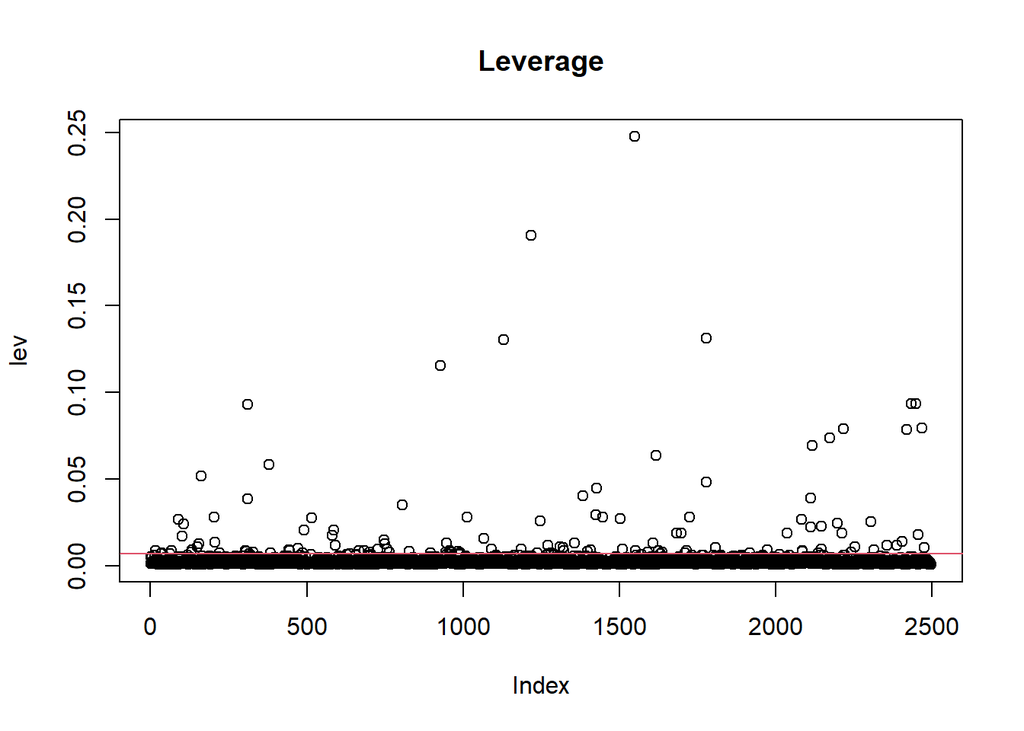

```r
lev = hatvalues(mod6)
p=sum(lev)
soglia = 2*p/n
plot(lev, main = 'Leverage')
abline(h=soglia, col=2)
```

```r
lev[lev>soglia]
```

```
##          15          36          61          67          89         101
## 0.009048691 0.007586090 0.007228057 0.008819093 0.027052656 0.017400328
##         106         131         134         151         155         161
## 0.024210645 0.008029374 0.009187696 0.010978820 0.012965880 0.051859899
##         204         206         220         304         305         310
## 0.028401132 0.013744457 0.007766249 0.008995691 0.008370814 0.093087112
##         312         317         328         378         383         442
## 0.038653516 0.007361155 0.008048617 0.058586108 0.007698016 0.009392959
##         445         471         486         492         516         582
## 0.009028601 0.010255276 0.007443625 0.020836775 0.027700559 0.017640045
##         587         592         666         684         702         729
## 0.020739989 0.011950789 0.008881300 0.008883607 0.008188061 0.009885864
##         748         750         757         765         805         828
## 0.014976995 0.013009864 0.009599869 0.008018802 0.035455005 0.008354344
##         895         928         946         947         956         964
## 0.007435489 0.115424243 0.007900357 0.013180181 0.009128513 0.008001347
##         985         991        1014        1067        1091        1130
## 0.008560124 0.007605428 0.028090095 0.016010108 0.009732232 0.130296729
##        1187        1218        1237        1247        1272        1282
## 0.009631923 0.190578096 0.007652788 0.026022226 0.012099485 0.007582980
##        1310        1320        1322        1356        1383        1398
## 0.010944099 0.010746899 0.008757891 0.013190310 0.040550900 0.008440155
##        1409        1426        1427        1448        1503        1511
## 0.009429128 0.029577896 0.044757684 0.028262917 0.027330588 0.009656059
##        1549        1551        1591        1608        1617        1626
## 0.247441499 0.008801328 0.007847029 0.013173536 0.063886970 0.009069833
##        1637        1684        1699        1710        1716        1725
## 0.008130575 0.019073413 0.018912188 0.007395406 0.008927547 0.028108164
##        1778        1779        1807        1918        1975        2038
## 0.131292359 0.048252479 0.010597920 0.007763067 0.009298583 0.018888645
##        2084        2085        2087        2112        2113        2118
## 0.027036149 0.008294726 0.008999216 0.039024848 0.022351432 0.069668707
##        2138        2146        2147        2173        2198        2214
## 0.007469431 0.009573236 0.022970261 0.073953708 0.024650565 0.018799750
##        2219        2242        2255        2305        2315        2357
## 0.079105361 0.008238344 0.011157025 0.025479222 0.009319296 0.011988474
##        2389        2406        2420        2435        2450        2456
## 0.011991509 0.014189333 0.078585852 0.093663142 0.093765409 0.018311074
##        2469        2476
## 0.079500219 0.010849538
```

```r
n_lev = length(lev[lev>soglia])
n_lev
```

```
## [1] 116
```

```r
max(lev)
```

```
## [1] 0.2474415
```

Il seguente grafico consente, invece, di identificare gli outliers.

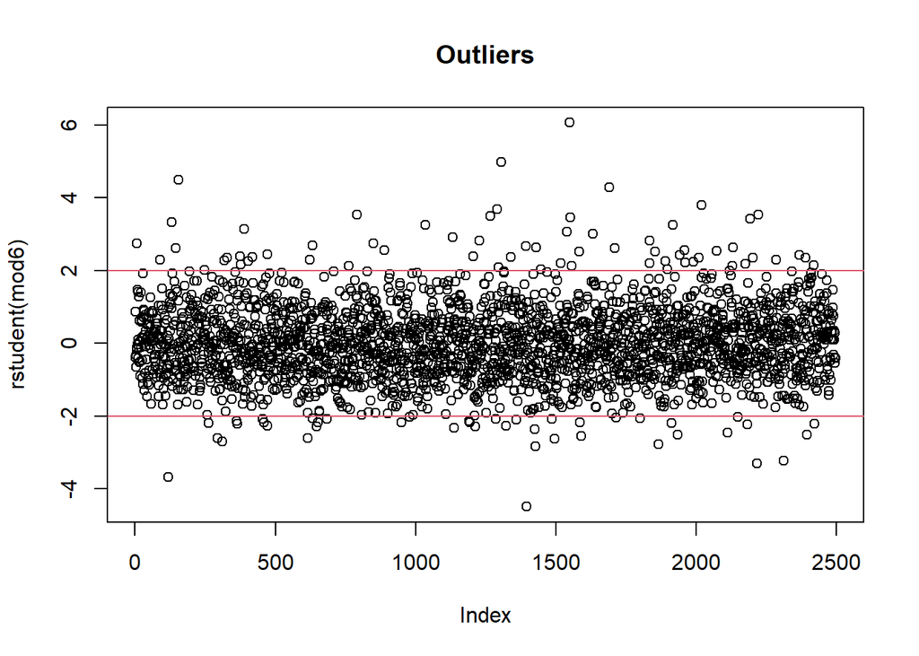

```r
plot(rstudent(mod6), main = 'Outliers')
abline(h=c(-2,2),col=2)
```

```r
out = outlierTest(mod6)
out
```

```
##       rstudent unadjusted p-value Bonferroni p
## 1549  6.067086         1.5014e-09   3.7504e-06
## 1305  4.980675         6.7707e-07   1.6913e-03
## 155   4.504890         6.9474e-06   1.7355e-02
## 1397 -4.492745         7.3524e-06   1.8366e-02
## 1692  4.298151         1.7886e-05   4.4678e-02
```

In particolare sono stati idenficati 5 punti come outlier.